# The Hidden Language of Healthcare Data

An Exploratory Data Analysis of FHIR Resources from the Global Implementation Guide Registry

Suhas P K

March 07, 2026

## The Problem Nobody Talks About

Imagine you’re a cardiologist, and your patient walks in for a follow-up after a surgery done at a different hospital across town. You ask your software to pull their records. It can’t. The other hospital runs a different system. Their data lives in a different format, behind a different API, using different code systems for the same diagnosis.

This isn’t a rare edge case. This is **the daily reality of U.S. healthcare**.

The American health system processes over **5 billion clinical encounters per year**, yet the data generated by those encounters is trapped in silos — EPIC speaks one dialect, Cerner speaks another, insurance systems speak a third. The result: redundant tests, delayed diagnoses, medication errors, and an estimated **$8.3 billion in administrative waste** per year attributed to lack of interoperability alone.

Someone had to build a universal translator.

**The central question of this analysis:** How far has the FHIR ecosystem actually grown? Who is driving it? And what does the global distribution of FHIR resources tell us about where healthcare interoperability is winning — and where it still has miles to go?

## Enter FHIR

In 2014, HL7 International released the first draft of **FHIR** — *Fast Healthcare Interoperability Resources* — a standard designed to make healthcare data as easy to share as a REST API call.

The insight was simple but radical: instead of defining a single monolithic data model (like HL7 v2 and v3 tried to do), FHIR breaks healthcare data into discrete, self-describing **Resources** — Patient, Observation, Medication, AllergyIntolerance, Claim, and hundreds more. Each Resource has a defined structure, a canonical URL, a version, and can be published as part of an **Implementation Guide (IG)** — a bundled rulebook that tells developers exactly how to use FHIR for a specific clinical context.

The **FHIR XIG (Extended Implementation Guide) Registry** is HL7’s global catalog of every published FHIR package. It is, in essence, a living map of how the world is adopting healthcare interoperability. That is what we explore here.

## 1. The Scale of the Ecosystem

Before diving into the patterns, let’s set the stage with the numbers that define the dataset.

75,411

Resource Entries

1,096

Published Packages (IGs)

23

Distinct Resource Types

4

Contributing Authors

These aren’t just big numbers. Each of those resource entries represents a **structured, machine-readable definition of a healthcare concept** — a blood pressure reading format, a medication dosage template, a patient consent record — published by a health system, a government agency, or an open-source community somewhere in the world.

The fact that over **1,096 packages** exist means that 1,096 teams — from tiny clinics to CMS itself — have invested in publishing their healthcare data contracts publicly. That is the ecosystem.

## 2. A Standard, Six Editions

FHIR isn’t a single specification. It has gone through six major versions, each adding new resource types, refining existing ones, and deprecating concepts that the community outgrew.

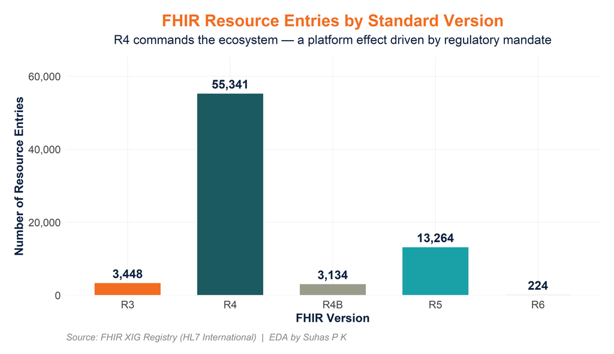

FHIR R4 is the undisputed majority version — adopted by CMS, ONC, Epic, and essentially every major healthcare software vendor.

```r
version_data <- res %>%
  filter(!is.na(version), version != "") %>%
  count(version) %>%
  mutate(version = factor(version, levels = VERSION_ORDER)) %>%
  arrange(version)

ggplot(version_data, aes(x = version, y = n, fill = version)) +
  geom_col(show.legend = FALSE, width = 0.65, color = "white") +
  geom_text(aes(label = scales::comma(n)), vjust = -0.55,
            fontface = "bold", color = HC_NAVY, size = 6.5) +
  scale_y_continuous(labels = scales::comma,
                     expand = expansion(mult = c(0, 0.18))) +
  scale_fill_hc() +
  labs(
    title    = "FHIR Resource Entries by Standard Version",
    subtitle = "R4 commands the ecosystem — a platform effect driven by regulatory mandate",
    x        = "FHIR Version",
    y        = "Number of Resource Entries",
    caption  = CAPTION
  ) +
  theme_hc()
```

Key Insight

**FHIR R4 isn’t just dominant — it’s a platform.** When the U.S. Department of Health and Human Services codified FHIR R4 into the **CMS Interoperability and Patient Access Final Rule (CMS-9115-F)** in 2020, it didn’t just recommend R4. It *required* it. Every Medicare and Medicaid payer had to implement FHIR R4 APIs by mid-2021. That mandate turned R4 from a standard into a *network effect* — vendors built for R4, patients received R4, and new IGs defaulted to R4. This is what regulatory tailwind looks like in data.

### The Growth Trajectory

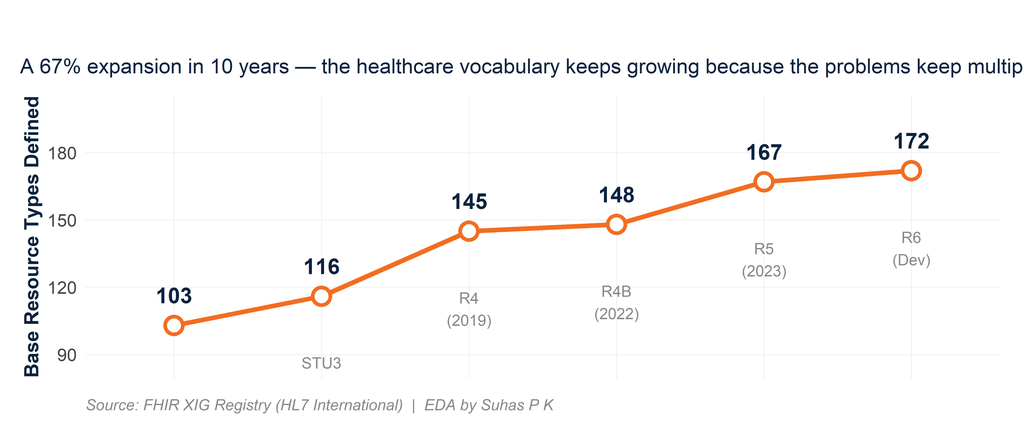

```r
# FHIR base resource type counts by version (sourced from HL7 spec documentation)
fhir_evolution <- tibble(
  version = factor(VERSION_ORDER, levels = VERSION_ORDER),
  types   = c(103L, 116L, 145L, 148L, 167L, 172L),
  label   = c("DSTU2\n(2015)", "STU3\n(2017)", "R4\n(2019)",
              "R4B\n(2022)", "R5\n(2023)", "R6\n(Dev)")
)

ggplot(fhir_evolution, aes(x = version, y = types, group = 1)) +
  geom_area(fill = HC_ORANGE, alpha = 0.15) +
  geom_line(color = HC_ORANGE, linewidth = 2) +
  geom_point(color = HC_ORANGE, size = 6, shape = 21,
             fill = "white", stroke = 2.5) +
  geom_text(aes(label = types), vjust = -1.4,
            fontface = "bold", color = HC_NAVY, size = 7) +
  geom_text(aes(label = label), vjust = 2.8,
            color = "#888", size = 5) +
  scale_y_continuous(limits = c(85, 200),
                     breaks = seq(90, 200, by = 30)) +
  labs(
    title    = "Growth in FHIR Base Resource Types: 2015 → Present",
    subtitle = "A 67% expansion in 10 years — the healthcare vocabulary keeps growing because the problems keep multiplying",
    x        = NULL,
    y        = "Base Resource Types Defined",
    caption  = CAPTION
  ) +
  theme_hc() +
  theme(axis.text.x = element_blank())
```

In 10 years, FHIR’s core vocabulary has grown from **103 resource types to 172** — a 67% expansion. New types like `DeviceRequest`, `NutritionOrder`, `ChargeItemDefinition`, and `SubscriptionStatus` didn’t exist in 2015. They were added because real clinicians, developers, and regulators identified gaps and the HL7 community filled them. This is a living standard, not a frozen one.

## 3. What Exactly IS a FHIR Resource?

Not all FHIR resources represent clinical events. In fact, the most common types in the registry are *structural* — the building blocks that other resources are made of.

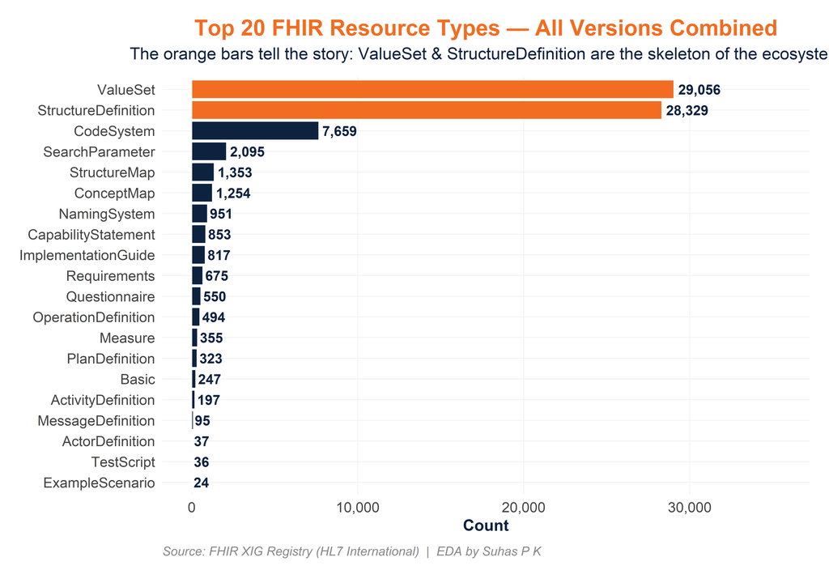

```r
top20 <- res %>%
  filter(!is.na(resource_type), resource_type != "") %>%
  count(resource_type, sort = TRUE) %>%
  slice_head(n = 20) %>%
  mutate(
    resource_type = fct_reorder(resource_type, n),
    is_top2 = resource_type %in% c("ValueSet", "StructureDefinition")
  )

ggplot(top20, aes(x = resource_type, y = n,
                  fill = ifelse(is_top2, HC_ORANGE, HC_NAVY))) +
  geom_col(show.legend = FALSE, color = "white") +
  geom_text(aes(label = scales::comma(n)), hjust = -0.1,
            fontface = "bold", color = HC_NAVY, size = 5.5) +
  coord_flip() +
  expand_limits(y = max(top20$n) * 1.22) +
  scale_y_continuous(labels = scales::comma) +
  scale_fill_identity() +
  annotate("text", x = 19.5, y = max(top20$n) * 0.75,
           label = "▲ Together ~76%\nof all resources",
           color = HC_ORANGE, fontface = "bold", size = 5.5, hjust = 0.5) +
  labs(
    title    = "Top 20 FHIR Resource Types — All Versions Combined",
    subtitle = "The orange bars tell the story: ValueSet & StructureDefinition are the skeleton of the ecosystem",
    x        = NULL,
    y        = "Count",
    caption  = CAPTION
  ) +
  theme_hc()
```

**What is a StructureDefinition?** Think of it as a **data schema with healthcare semantics** — it defines exactly what fields a Patient record must have, which are required vs optional, and what vocabulary terms are allowed. Every time you see a FHIR profile for US Core Patient or Da Vinci Coverage, there’s a StructureDefinition underneath.

**What is a ValueSet?** It’s an **allowed list of codes** — like a dropdown list that says “the only valid values for gender in this system are: male, female, other, unknown.” Healthcare terminologies (SNOMED CT, LOINC, ICD-10, RxNorm) expose their content as ValueSets in FHIR.

Together, they are the grammar and the vocabulary. Every other resource type is built from them.

### Composition Across Versions

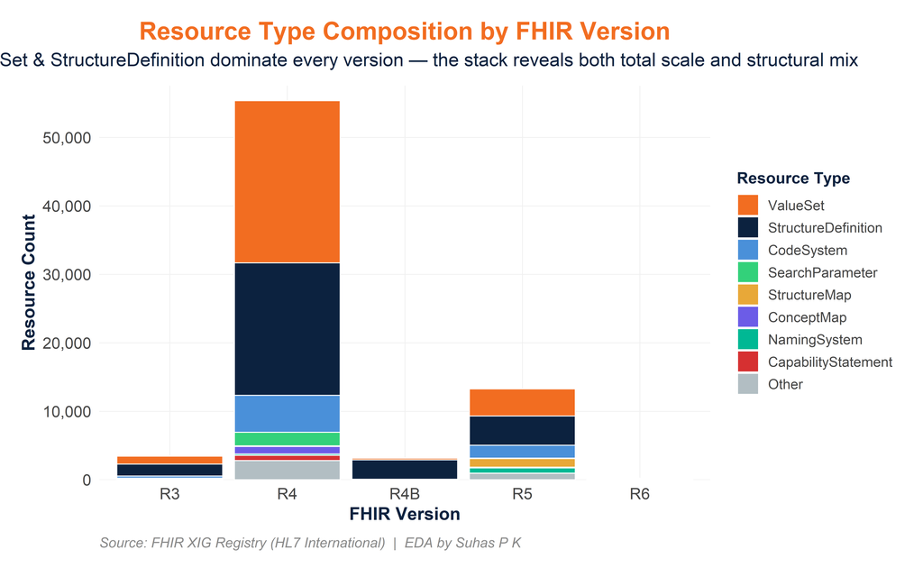

```r
top8_types <- res %>%
  filter(!is.na(resource_type), resource_type != "") %>%
  count(resource_type, sort = TRUE) %>%
  slice_head(n = 8) %>%
  pull(resource_type)

type_colors_stack <- setNames(
  c(HC_ORANGE, HC_NAVY, HC_BLUE, HC_GREEN, HC_GOLD, HC_PURPLE, HC_TEAL, HC_RED, "#b2bec3"),
  c(top8_types, "Other")
)

stacked_data <- res %>%
  filter(!is.na(version), version != "",
         !is.na(resource_type), resource_type != "") %>%
  mutate(
    type_group = if_else(resource_type %in% top8_types, resource_type, "Other"),
    type_group = factor(type_group, levels = c(top8_types, "Other")),
    version    = factor(version, levels = VERSION_ORDER)
  ) %>%
  count(version, type_group)

ggplot(stacked_data, aes(x = version, y = n, fill = type_group)) +
  geom_col(position = "stack", color = "white", linewidth = 0.5) +
  scale_y_continuous(labels = scales::comma,
                     expand = expansion(mult = c(0, 0.04))) +
  scale_fill_manual(values = type_colors_stack, name = "Resource Type") +
  labs(
    title    = "Resource Type Composition by FHIR Version",
    subtitle = "ValueSet & StructureDefinition dominate every version — the stack reveals both total scale and structural mix",
    x        = "FHIR Version",
    y        = "Resource Count",
    caption  = CAPTION
  ) +
  theme_hc() +
  theme(legend.position  = "right",
        legend.key.size  = unit(0.8, "cm"),
        legend.text      = element_text(size = 14),
        legend.title     = element_text(size = 16, face = "bold"))
```